# Trends Among Lego Sets

Stat 209 - Project 2

Julian Grabarek

Dizzy Farbanish

Jamie Catterall

Ben Yost

We explored trends among Lego sets found in the Lego database from Kaggle. The database contains data on all the Lego sets up to July 2017.

The data sets contained csv files on the following:

- *colors* - an index of lego colors
- *inventories* - the packages containing parts by set
- *inventory_parts* - which parts are in an inventory
- *inventory_sets* - which inventories were in each set
- *part_catagories* - which catagory a part belongs to
- *parts* - an index of different lego parts
- *sets* - an index of Lego sets
- *themes* - an index of lego themes, e.g. Star Wars

Our visualizations focus on how Lego sets have diversified over time.

As can be seen above, the data sets focus on themes, sets, inventories, and parts. We did not focus on themes, but we did use data involving colors, sets, parts and inventories. Joining sets, and inventories was important inorder to compare data concerning parts with the year, set_num, part_num, and inventory_id were key variables in making our visualizations.

Source: https://www.kaggle.com/rtatman/lego-database

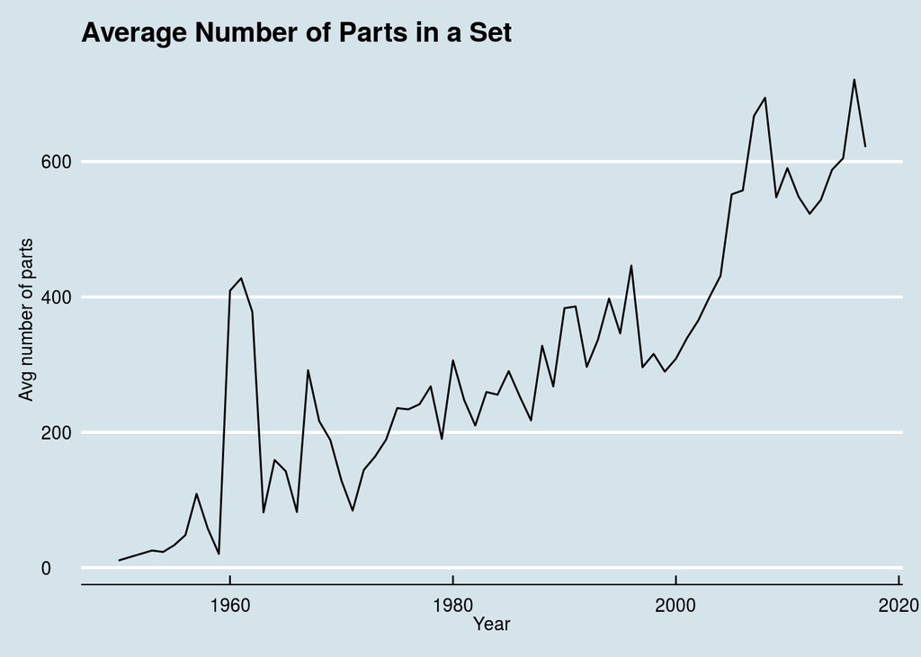

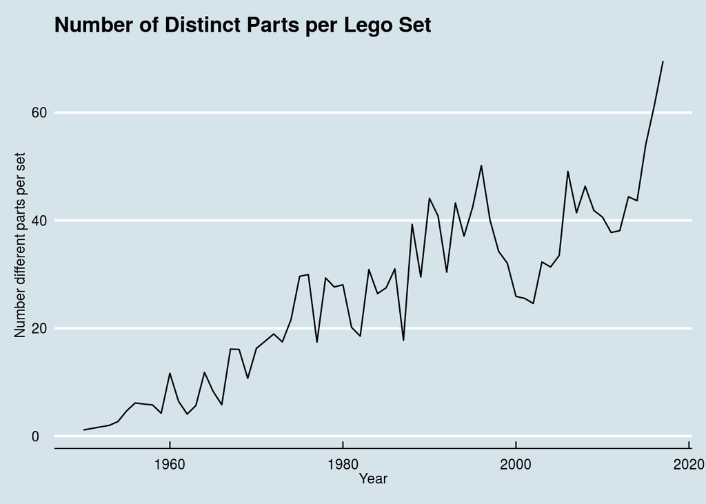

In these two graphs we see different ways to view the proliferation of Lego sets. In the first, we see the total number of parts in a set has gotten larger over time. In the second we see that the number of different parts in a set has expanded. Thus, over time lego sets have become increasingly larger and more complex. There is a significant drop in the years around 2000 in both graphs. A possible explanation for this trend could be explained by a quick graph of the number of sets per year.

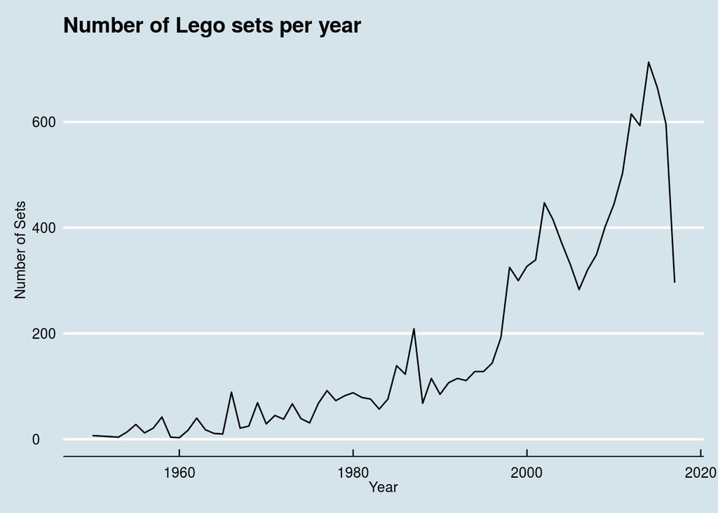

As we see in this graph, the number of lego sets per year dramatically increased around the year 2000. The drop in size and complexity of sets around the same time could be explained by this increase. As Lego producers started producing more and more sets, they scaled-back size and complexity in favor of increased numbers of sets.

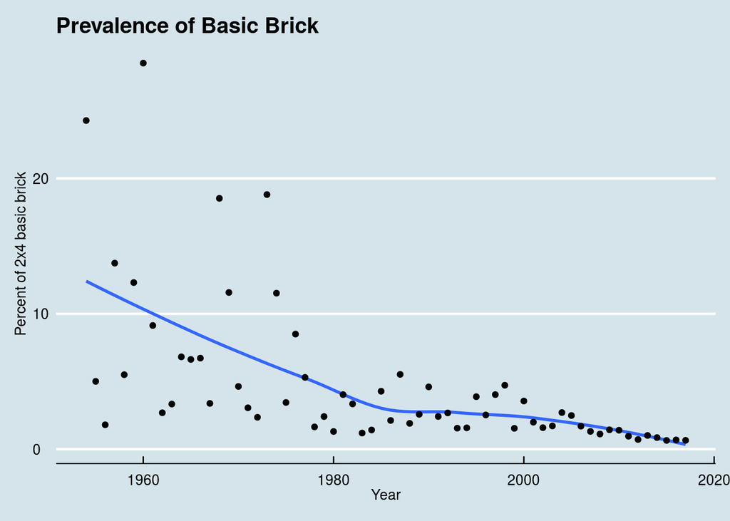

This graph shows the prevalence of the basic 2 by 4 lego brick over time. The graph shows the ratio of Lego bricks in every type of set to total bricks in every type of set for every year provided in the data set. The data suggests that Lego have moved away from basic brick structures over the years. Changes in this ratio by year were sporatic in early years and gradually became more consistent.

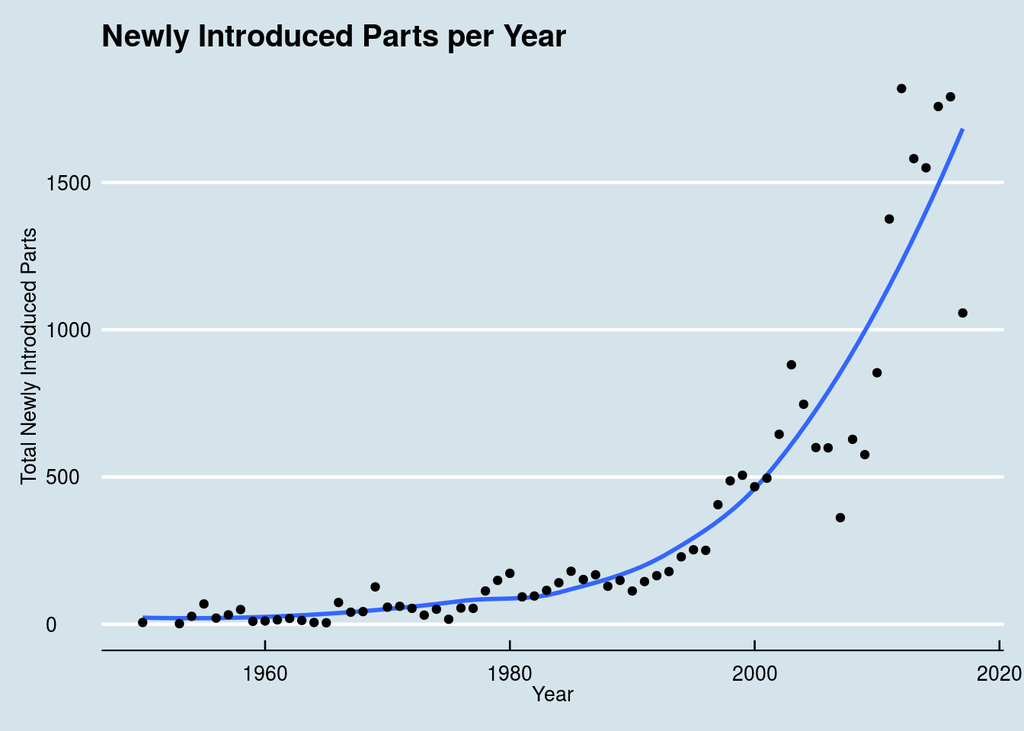

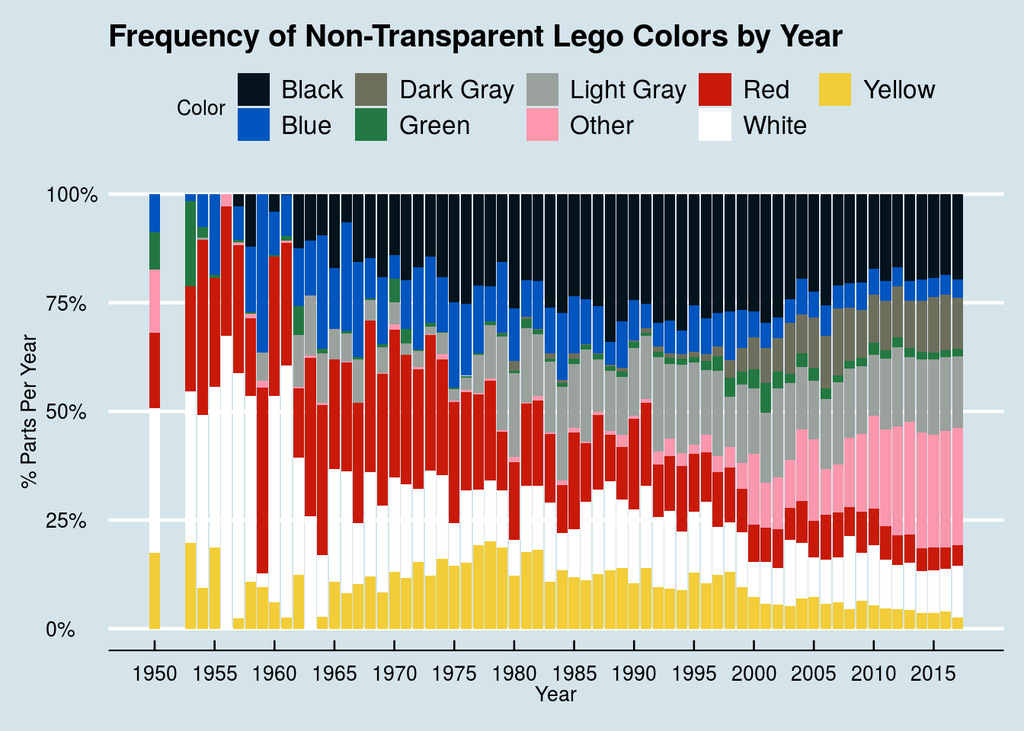

This bar graph shows how often various non-transparent colors show up in Lego sets released every year - more specifically, the ratio of the number of Lego parts of a specific color found in sets released every year, to the total number of Lego pieces found in sets released every year. For the first few decades, the vast majority of the pieces found in each year’s sets are one of a few colors: primarily Red, Blue, Black, White, Yellow, and from the 1960s onward, Light Gray. However, the 1990s is when the proportion of opaque pieces that are not one of those colors slowly starts to increase, before jumping to about 15% of all non-opaque pieces in the year 2000. From 2012 onward, at least one out of every four non-transparent pieces found in each year’s sets is a color outside of the “traditional” Lego colors. Just like Lego sets have become bigger, more complicated, more innovative, and more numerous in the last 30 years, the colors in Lego sets have become more diverse.

# Methodology

The data download included a map of how each of the tables were related to each other. When we were joining tables, we used this schema as the path for joins. We used `left_join()` when we were using sets as the unit of analysis since we wanted to keep all the sets in the final joined table.

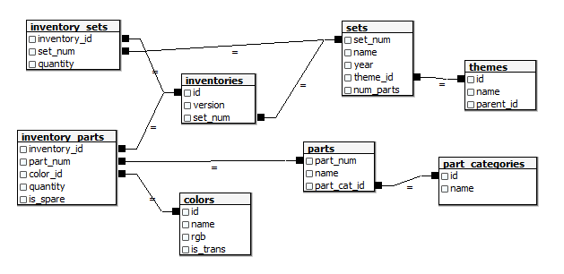

Download schema for Lego data (Taken from Kaggle).

For the graphs that were comparing number of set parts by year, we mostly used `group_by(year)` and `summarize()`.

For many of the graphs, we chose a scatterplot with a trendline (using geom_smooth), as it was the best way to represent a number of individual data points over time. Geom_smooth helps the trend in the data be clearly visualized, such as in the new parts per year graph.